# R Notebook

# Series de tiempo: comparativa entre un modelo ARIMA y prophet

### Introducción

Importamos las librerías a utilizar

```r
rm(list=ls())

require(dplyr)
require(ggplot2)
require(ggfortify)
require(tsibble)
require(lubridate)
require(prophet)
require(forecast)
```

### Análisis exploratorio

Importamos los datasets con los que se va a trabajar:

```r
df_abc <- read.csv("./datasets/202208_PAX15min-ABC.csv", sep=";")
df_deh <- read.csv("./datasets/202208_PAX15min-DEH.csv", sep=";")

df <- bind_rows(df_abc, df_deh)
rm(df_abc, df_deh)
print(colnames(df))
```

```
 [1] "FECHA"           "DESDE"           "HASTA"           "LINEA"
 [5] "MOLINETE"        "ESTACION"        "pax_pagos"       "pax_pases_pagos"
 [9] "pax_franq"       "pax_TOTAL"
```

Agrupamos la información a nivel estación/horario y convertimos a formato fecha/hora:

```r
df_linea <- df %>%
  group_by(FECHA,DESDE,HASTA,LINEA,ESTACION) %>%
  summarize(pasajeros = sum(pax_TOTAL)) %>%
  mutate(ts = dmy_hms(paste0(FECHA," " ,DESDE)))%>%
  ungroup() %>%
  select(-c(FECHA, DESDE, HASTA))
```

Agrupamos por linea y observamos la cantidad de pasajeros para cada una de ellas:

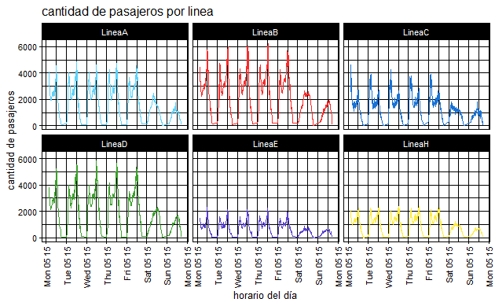

```r
df_linea %>%
  filter(ts >= "2022-08-01 05:15:00" & ts <= "2022-08-07 23:15:00") %>%
  group_by(LINEA, ts) %>%
  summarise(pasajeros = sum(pasajeros)) %>%
  ggplot() +
  aes(x = ts, y = pasajeros, fill = LINEA, colour = LINEA, group = LINEA) +
  geom_line(size = 0.5) +
  scale_fill_manual(values = c(LineaA = "#5CD2FB", LineaB = "#FD2929", LineaC = "#1872D6", LineaD = "#39A029", LineaE = "#583FD2", LineaH = "#FFEC3B")) +
  scale_color_manual(values = c(LineaA = "#5CD2FB", LineaB = "#FD2929", LineaC = "#1872D6", LineaD = "#39A029", LineaE = "#583FD2", LineaH = "#FFEC3B")) +
  labs(x = "horario del día", y = "cantidad de pasajeros", title = "cantidad de pasajeros por linea") +
  theme_linedraw() +
  theme(legend.position = "none") +
  facet_wrap(vars(LINEA)) +
  scale_x_datetime(breaks= seq(min(df_linea$ts), max(df_linea$ts), by = "24 hour"), date_labels = "%a %H %M") +
  theme(axis.text.x = element_text(angle = 90, vjust = 0.5, hjust=1))
```

Para el análisis, nos vamos a quedar con la información de la estación palermo de la linea D y vamos a trabajar con los siguientes períodos:

Train: 1/08/2022 al 21/08/2022 Test: 22/08/2022 al 28/08/2022

```r
df_analisis <- df_linea %>%
  filter(ts > "2022-08-01" & ts < "2022-08-29" & ESTACION == "Palermo") %>%
  mutate(ts = floor_date(ts, unit = 'hour')) %>%
  group_by(ts) %>%
  summarise(y = sum(pasajeros)) %>%
  rename(ds = ts) %>%
  mutate(dia_semana = as.character(wday(ds, label=TRUE)),
         dia_numero = wday(ds),
         hora = as.character(hour(ds)),
         ndays = as.numeric(difftime(as.Date(ds),as.Date(ds)[1],units="days")),
         time_index = row_number()) %>%
  as_tsibble(index = ds)

df_train <- df_analisis %>%
  filter(ds < "2022-08-22")

df_test <- df_analisis %>%
  filter(ds > "2022-08-22")
```

Observo la serie:

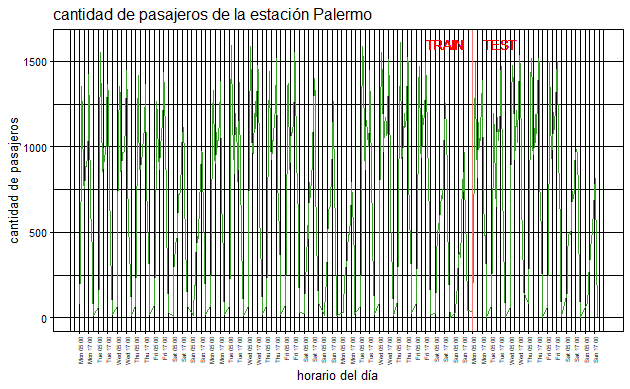

```r
df_analisis %>%
  ggplot(aes(x = ds, y=y)) +
  geom_line(colour = "#39A029") +
  labs(x = "horario del día", y = "cantidad de pasajeros", title = "cantidad de pasajeros de la estación Palermo") +
  theme_linedraw() +
  theme(legend.position = "none") +
  scale_x_datetime(breaks= seq(min(df_analisis$ds), max(df_analisis$ds), by = "12 hour"), date_labels = "%a %H %M") +
  theme(axis.text.x = element_text(angle = 90, vjust = 0.5, hjust=1, size = 5)) +
  geom_vline(aes(xintercept=min(df_test$ds), color='red')) +
  geom_text(aes(x=min(df_test$ds) , label="TRAIN     TEST", y=1600), colour="red", angle=0)
```

```r
NA
NA
NA
```

En primer lugar, se va a armar una regresión lineal con la tendencia y las variables estacionales. Luego, utilizará ARIMA para intentar captar cierto componente autoregresivo en la serie.

### ARIMA

```r
#Defino serie temporal con las 18 horas laborales separando por dia
ts_train <- ts(df_train[-1],freq=18)

#Queda la serie univariada
ts_train <- ts_train [,'y']
```

Se observa que la serie presenta coeficientes de autocorrelación se presentan por fuera de la banda azul, que indica que las mismas son significativamente diferentes de 0.

### ¿Es la serie estacionaria?

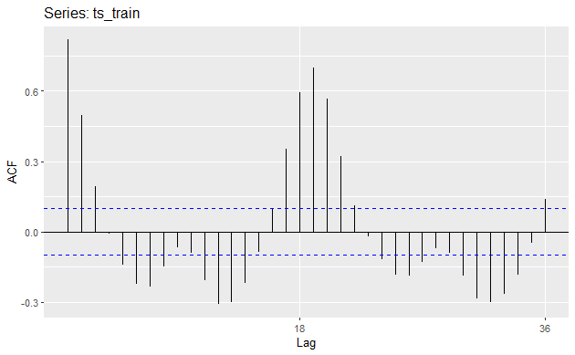

```r
ggAcf(ts_train)
```

## Estacionalidad y tendencia

[figure not shown]

Para saber si se debe diferenciar la serie se puede utilizar un test “Unit Root”. Se emplea a continuación el test KPSS(Kwiatkowski-Phillips-Schmidt-Shin), cuya hipótesis nula es que los datos son estacionarios. p-valores inferiores a 0,05 sugieren que se debe diferenciar la serie

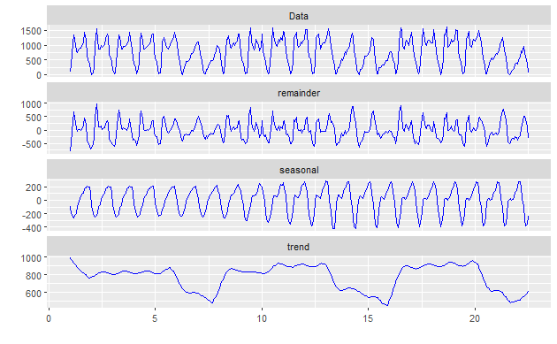

```r
#Grafico considerando una estacionalidad horaria
ts_train %>%
  stl(s.window = 18) %>%
  autoplot(ts.colour='blue')
```

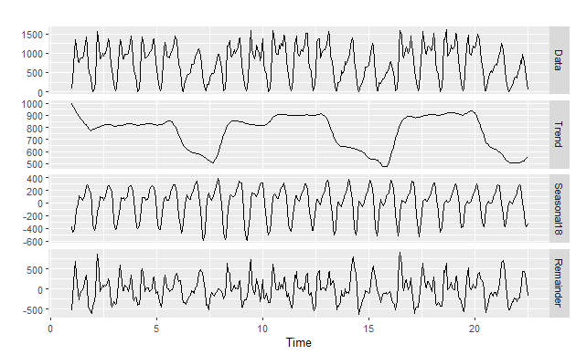

```r
#Dando el parámetro automatico se obtiene

ts_train %>%
  mstl() %>%
  autoplot()
```

```r
ts_train %>% ur.kpss() %>%  summary()
```

```
#######################
# KPSS Unit Root Test #
#######################

Test is of type: mu with 5 lags.

Value of test-statistic is: 0.0711

Critical value for a significance level of:
                10pct  5pct 2.5pct  1pct
critical values 0.347 0.463  0.574 0.739
```

#### Implementación modelo ARIMA automático

Se implementa la función auto.arima, que realiza los siguientes pasos para obtener el modelo ARIMA(p,d,q):

1. Búsqueda del número de diferencias con test KPSS como se realizó anteriormente sobre la serie.
2. Valores de “p” y “q” se obtienen minimizando el AIC luego de diferenciar la serie. No se prueban todos los modelos si no que se adoptan 4 modelos iniciales para realizar la búsqueda de los parámetros

Sin embargo, este procedimiento no verifica tener ruido blanco en los residuos del modelo, por lo se procede a hacer un ARIMA manual

```r
ts_train %>% diff() %>% ur.kpss() %>%  summary()
```

```
#######################
# KPSS Unit Root Test #
#######################

Test is of type: mu with 5 lags.

Value of test-statistic is: 0.022

Critical value for a significance level of:
                10pct  5pct 2.5pct  1pct
critical values 0.347 0.463  0.574 0.739
```

A continuación los valores predichos, que no entregan un resultado similar al comportamiento estacionario de la serie.

```r
summary(auto_arima)
```

```
Series: ts_train
ARIMA(5,0,3)(2,0,0)[18] with non-zero mean

Coefficients:
         ar1      ar2     ar3      ar4      ar5      ma1
      1.6361  -1.7613  1.0582  -0.1428  -0.1966  -0.4768
s.e.  0.0768   0.1443  0.1726   0.1304   0.0591   0.0851
         ma2      ma3    sar1     sar2      mean
      0.9541  -0.1093  0.2015  -0.0352  756.2117
s.e.  0.0412   0.0791  0.0636   0.0521   37.7834

sigma^2 = 35409:  log likelihood = -2579.31
AIC=5182.62   AICc=5183.46   BIC=5230.16

Training set error measures:
                    ME     RMSE      MAE       MPE
Training set 0.4966308 185.4871 148.6883 -83.24618
                 MAPE      MASE        ACF1
Training set 108.8285 0.5102596 -0.00639353
```

#### ARMA manual

Para determinar los parámetros a utilizar, el parámetro “p” se obtiene del gráfico de PACF. Se prueba seteando el valor a 12, que se corresponde con las veces que significativamente el coeficiente toma valores por fuera del umbral para el primer ciclo

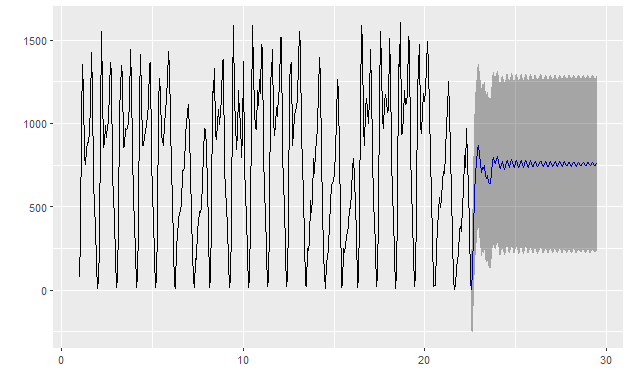

```r
valores_prediccion <- forecast(auto_arima,126)
autoplot(valores_prediccion)
```

Se observa un comportamiento sinusoidal en ambos gráficos de coeficientes, por lo que p y q deben ser distintos de 0.

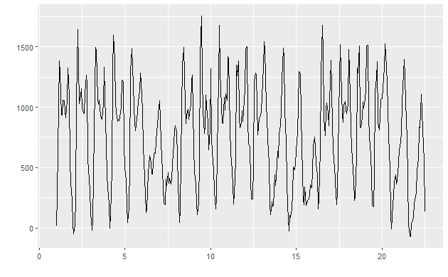

```r
ts_train %>% stl(s.window='periodic') %>% seasadj() -> ts_train_adj
autoplot(ts_train_adj)
```

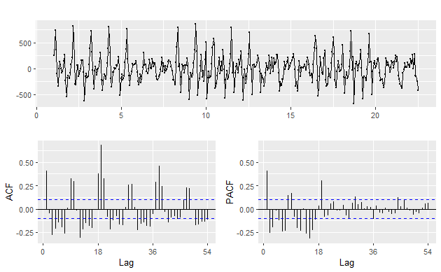

```r
ts_train_adj %>% diff() %>% ggtsdisplay(main='')
```

```r
#Verifico que sea estacional

ts_train_adj%>% diff() %>% ur.kpss() %>%  summary()
```

```
#######################
# KPSS Unit Root Test #
#######################

Test is of type: mu with 5 lags.

Value of test-statistic is: 0.0228

Critical value for a significance level of:
                10pct  5pct 2.5pct  1pct
critical values 0.347 0.463  0.574 0.739
```

Se observa que se debe combinar parámetros autoregresivos y de media móvil, y considerar la estacionalidad que presenta la serie.

### ARIMA estacional

```r
(fit <- Arima(ts_train_adj, order=c(12,1,0)))
```

```
Series: ts_train_adj
ARIMA(12,1,0)

Coefficients:
         ar1      ar2      ar3      ar4      ar5
      0.3144  -0.0587  -0.2039  -0.1232  -0.1090
s.e.  0.0492   0.0517   0.0517   0.0523   0.0529
          ar6      ar7      ar8     ar9     ar10
      -0.1081  -0.3164  -0.0227  0.1216  -0.0206
s.e.   0.0508   0.0507   0.0529  0.0525   0.0519
         ar11     ar12
      -0.1242  -0.2505
s.e.   0.0517   0.0497

sigma^2 = 36965:  log likelihood = -2579.83
AIC=5185.65   AICc=5186.63   BIC=5237.11
```

```
    Ljung-Box test

data:  Residuals from ARIMA(12,1,0)
Q* = 232.44, df = 24, p-value < 2.2e-16

Model df: 12.   Total lags used: 36
```

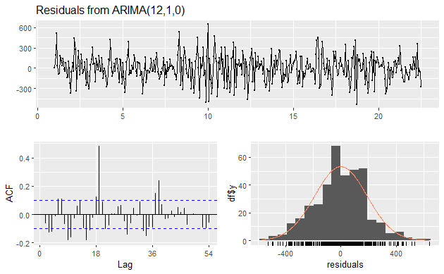

```r
checkresiduals(fit)
```

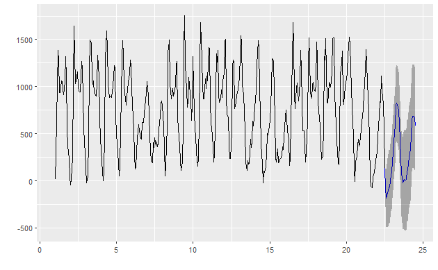

```r
autoplot(forecast(fit))
```

Efectuamos predicción para semana restante

```r
ts_train %>%
  Arima(order=c(5,0,0), seasonal=c(2,1,0), lambda=0) %>%
  forecast(h=126) %>%
  autoplot() +
    ylab("Predicción de conteo de molinetes") + xlab("Período")
```

[output not shown]

```r
forecast_arima <- forecast(Arima(ts_train,order=c(5,0,0), seasonal=c(2,1,0), lambda=0),h=126)
#Extraigo los valores medios de la serie
valores_arima <- forecast_arima$mean
```

```r
#Agrego el vector de predicciones a un nuevo df
df_prediccion <-  df_test
df_prediccion$arima_season <- NA_character_
df_prediccion$arima_season[seq_along(valores_arima)] <- valores_arima
df_prediccion$arima_season <- as.numeric(df_prediccion$arima_season)

#Calculo el RMSE
rmse(df_prediccion$y,df_prediccion$arima_season)
```

[output not shown]